# AMSTAR Scores in Cullis 2017: GPT 3.5 reproducibility

### Score comparisons of 112 publications

| Ref. | Author & Year | AMSTAR κ | AMSTAR agreement |
| --- | --- | --- | --- |
| 61 | Aikenhead 2011 | 0.467741935483871 | 0.727272727272727 |
| 62 | Al-Hozaim 2010 | 1 | 1 |
| 63 | Allen 2015 | 0.541666666666667 | 0.727272727272727 |
| 64 | Allin 2015 | 1 | 1 |
| 65 | Alzahem 2011 | 0.694444444444444 | 0.818181818181818 |
| 66 | Apelt 2013 | 1 | 1 |
| 67 | Aworanti 2014 | 0.702702702702703 | 0.818181818181818 |
| 68 | Baker 2015 | -0.0185185185185186 | 0.545454545454545 |
| 69 | Berger 2012 | 1 | 1 |
| 70 | Billingham 2010 | 1 | 1 |

[output cut: 102 more lines]

### Score heatmaps

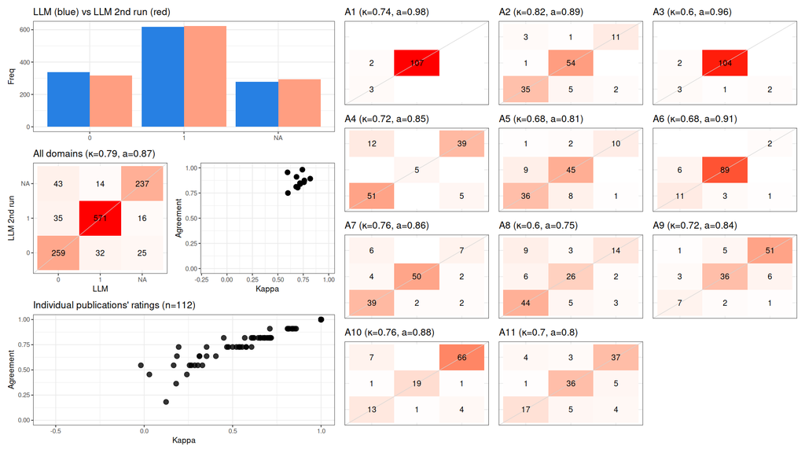

### Individual results

#### 61. [Aikenhead 2011: *Effectiveness and cost-effectiveness of paediatric bariatric surgery: a systematic review*](https://doi.org/10.1111/J.1758-8111.2010.00003.X)

AMSTAR

|  | A1 | A2 | A3 | A4 | A5 | A6 | A7 | A8 | A9 | A10 | A11 |
| --- | --- | --- | --- | --- | --- | --- | --- | --- | --- | --- | --- |
| LLM | 1 | 1 | 1 | 1 | 1 | 1 | 1 | 1 | 0 | NA | 1 |
| LLM 2nd run | 1 | 0 | 1 | 1 | 0 | 1 | 1 | 1 | 0 | NA | NA |

#### 62. [Al-Hozaim 2010: *Laparoscopic-assisted anorectal pull-through for anorectal malformations: a systematic review and the need for standardization of outcome reporting*](https://doi.org/10.1016/J.JPEDSURG.2009.12.001)

AMSTAR

|  | A1 | A2 | A3 | A4 | A5 | A6 | A7 | A8 | A9 | A10 | A11 |
| --- | --- | --- | --- | --- | --- | --- | --- | --- | --- | --- | --- |
| LLM | 1 | NA | 1 | NA | 1 | 1 | 1 | 1 | 0 | NA | NA |
| LLM 2nd run | 1 | NA | 1 | NA | 1 | 1 | 1 | 1 | 0 | NA | NA |

#### 63. [Allen 2015: *Pediatric emergency department thoracotomy: A large case series and systematic review*](https://doi.org/10.1016/J.JPEDSURG.2014.10.042)

AMSTAR

|  | A1 | A2 | A3 | A4 | A5 | A6 | A7 | A8 | A9 | A10 | A11 |
| --- | --- | --- | --- | --- | --- | --- | --- | --- | --- | --- | --- |
| LLM | 1 | 0 | 1 | NA | NA | 1 | 0 | 0 | NA | NA | NA |
| LLM 2nd run | 1 | NA | 1 | NA | NA | 1 | NA | NA | NA | NA | NA |

#### 64. [Allin 2015: *Challenges of Improving the Evidence Base in Smaller Surgical Specialties, as Highlighted by a Systematic Review of Gastroschisis Management*](https://doi.org/10.1371/JOURNAL.PONE.0116908)

AMSTAR

|  | A1 | A2 | A3 | A4 | A5 | A6 | A7 | A8 | A9 | A10 | A11 |
| --- | --- | --- | --- | --- | --- | --- | --- | --- | --- | --- | --- |
| LLM | 1 | 1 | 1 | NA | 1 | 1 | 1 | 1 | 1 | NA | 1 |
| LLM 2nd run | 1 | 1 | 1 | NA | 1 | 1 | 1 | 1 | 1 | NA | 1 |

#### 65. [Alzahem 2011: *Laparoscopic versus open inguinal herniotomy in infants and children: a meta-analysis*](https://doi.org/10.1007/S00383-010-2840-X)

AMSTAR

|  | A1 | A2 | A3 | A4 | A5 | A6 | A7 | A8 | A9 | A10 | A11 |
| --- | --- | --- | --- | --- | --- | --- | --- | --- | --- | --- | --- |
| LLM | 1 | 1 | 1 | 0 | 1 | 0 | 1 | 0 | 1 | 0 | NA |
| LLM 2nd run | 1 | 1 | 1 | 0 | 0 | 0 | 1 | 0 | 0 | 0 | NA |

#### 66. [Apelt 2013: *Laparoscopic treatment of intussusception in children: A systematic review*](https://doi.org/10.1016/J.JPEDSURG.2013.05.024)

AMSTAR

|  | A1 | A2 | A3 | A4 | A5 | A6 | A7 | A8 | A9 | A10 | A11 |
| --- | --- | --- | --- | --- | --- | --- | --- | --- | --- | --- | --- |
| LLM | 1 | NA | 1 | NA | 0 | 1 | 1 | NA | 1 | NA | NA |
| LLM 2nd run | 1 | NA | 1 | NA | 0 | 1 | 1 | NA | 1 | NA | NA |

#### 67. [Aworanti 2014: *Management of Recurrent Tracheoesophageal Fistulas: A Systematic Review*](https://doi.org/10.1055/S-0034-1370780)

AMSTAR

|  | A1 | A2 | A3 | A4 | A5 | A6 | A7 | A8 | A9 | A10 | A11 |
| --- | --- | --- | --- | --- | --- | --- | --- | --- | --- | --- | --- |
| LLM | 1 | 0 | 1 | 0 | 0 | 1 | 0 | 0 | NA | NA | 1 |
| LLM 2nd run | 1 | 0 | 1 | 0 | 0 | 1 | 0 | 1 | NA | 0 | 1 |

#### 68. [Baker 2015: *A systematic review and meta-analysis of gastrostomy insertion techniques in children*](https://doi.org/10.1016/J.JPEDSURG.2015.02.021)

AMSTAR

|  | A1 | A2 | A3 | A4 | A5 | A6 | A7 | A8 | A9 | A10 | A11 |
| --- | --- | --- | --- | --- | --- | --- | --- | --- | --- | --- | --- |
| LLM | 1 | 1 | 1 | 0 | 1 | 1 | 1 | 0 | 1 | NA | NA |
| LLM 2nd run | 1 | 1 | 1 | NA | 1 | 1 | 1 | 1 | NA | 1 | 1 |

#### 69. [Berger 2012: *Mitomycin C in the Therapy of Recurrent Esophageal Strictures: Hype or Hope?*](https://doi.org/10.1055/S-0032-1311695)

AMSTAR

|  | A1 | A2 | A3 | A4 | A5 | A6 | A7 | A8 | A9 | A10 | A11 |
| --- | --- | --- | --- | --- | --- | --- | --- | --- | --- | --- | --- |
| LLM | 1 | NA | 1 | NA | 1 | 1 | 0 | 0 | NA | NA | NA |
| LLM 2nd run | 1 | NA | 1 | NA | 1 | 1 | 0 | 0 | NA | NA | NA |

#### 70. [Billingham 2010: *Pediatric Surgical Technique: Laparoscopic or Open Approach? A systematic Review and Meta-Analysis*](https://doi.org/10.1055/S-0029-1241871)

AMSTAR

|  | A1 | A2 | A3 | A4 | A5 | A6 | A7 | A8 | A9 | A10 | A11 |
| --- | --- | --- | --- | --- | --- | --- | --- | --- | --- | --- | --- |
| LLM | 1 | 0 | 1 | 0 | 0 | 1 | 1 | 0 | NA | NA | 1 |
| LLM 2nd run | 1 | 0 | 1 | 0 | 0 | 1 | 1 | 0 | NA | NA | 1 |

#### 71. [Black 2013: *Bariatric surgery for obese children and adolescents: a systematic review and meta-analysis*](https://doi.org/10.1111/OBR.12037)

AMSTAR

|  | A1 | A2 | A3 | A4 | A5 | A6 | A7 | A8 | A9 | A10 | A11 |
| --- | --- | --- | --- | --- | --- | --- | --- | --- | --- | --- | --- |
| LLM | 1 | 0 | 1 | NA | 1 | 1 | 0 | 1 | 1 | 1 | NA |
| LLM 2nd run | 1 | NA | 1 | NA | 1 | 1 | NA | NA | 1 | 1 | 1 |

#### 72. [Borruto 2010: *Laparoscopic vs open varicocelectomy in children and adolescents: review of the recent literature and meta-analysis*](https://doi.org/10.1016/J.JPEDSURG.2010.07.007)

AMSTAR

|  | A1 | A2 | A3 | A4 | A5 | A6 | A7 | A8 | A9 | A10 | A11 |
| --- | --- | --- | --- | --- | --- | --- | --- | --- | --- | --- | --- |
| LLM | 1 | 0 | 1 | NA | 0 | 1 | 0 | 0 | NA | NA | NA |
| LLM 2nd run | 1 | 0 | 1 | NA | 0 | 1 | 0 | 0 | NA | NA | NA |

#### 73. [Castagnetti 2010: *Surgical Management of Primary Severe Hypospadias in Children: Systematic 20-Year Review*](https://doi.org/10.1016/J.JURO.2010.06.044)

AMSTAR

|  | A1 | A2 | A3 | A4 | A5 | A6 | A7 | A8 | A9 | A10 | A11 |
| --- | --- | --- | --- | --- | --- | --- | --- | --- | --- | --- | --- |
| LLM | 1 | 0 | 1 | 0 | 0 | 0 | 0 | 0 | NA | NA | NA |
| LLM 2nd run | 1 | 0 | 1 | 0 | 1 | 1 | 1 | 0 | NA | NA | NA |

#### 74. [Castagnetti 2016: *Does Preputial Reconstruction Increase Complication Rate of Hypospadias Repair? 20-Year Systematic Review and Meta-Analysis*](https://doi.org/10.3389/FPED.2016.00041)

AMSTAR

|  | A1 | A2 | A3 | A4 | A5 | A6 | A7 | A8 | A9 | A10 | A11 |
| --- | --- | --- | --- | --- | --- | --- | --- | --- | --- | --- | --- |
| LLM | 1 | 0 | 1 | 0 | 1 | 0 | 0 | 0 | 0 | 0 | 0 |
| LLM 2nd run | 1 | 0 | 1 | 0 | 1 | 1 | 1 | 0 | 1 | 0 | 0 |

#### 75. [Chan 2014 (Pediatr Surg Int): *Ideal timing of orchiopexy: a systematic review*](https://doi.org/10.1007/S00383-013-3429-Y)

AMSTAR

|  | A1 | A2 | A3 | A4 | A5 | A6 | A7 | A8 | A9 | A10 | A11 |
| --- | --- | --- | --- | --- | --- | --- | --- | --- | --- | --- | --- |
| LLM | 1 | 1 | 1 | 0 | 1 | 0 | 1 | 1 | NA | 1 | 0 |
| LLM 2nd run | 1 | 1 | 1 | 0 | 1 | 1 | 1 | 1 | NA | 0 | 0 |

#### 76. [Chan 2014 (J Pediatr Surg): *Minimally invasive versus open repair of Bochdalek hernia: a meta-analysis*](https://doi.org/10.1016/J.JPEDSURG.2014.02.049)

AMSTAR

|  | A1 | A2 | A3 | A4 | A5 | A6 | A7 | A8 | A9 | A10 | A11 |
| --- | --- | --- | --- | --- | --- | --- | --- | --- | --- | --- | --- |
| LLM | 1 | 1 | 1 | NA | 0 | 1 | 1 | 1 | 1 | 1 | NA |
| LLM 2nd run | 1 | NA | 1 | NA | 1 | 1 | 1 | 1 | 1 | 1 | NA |

#### 77. [Chang 2015: *Comparing the efficacy and safety between robotic-assisted versus open pyeloplasty in children: a systemic review and meta-analysis*](https://doi.org/10.1007/S00345-015-1526-3)

AMSTAR

|  | A1 | A2 | A3 | A4 | A5 | A6 | A7 | A8 | A9 | A10 | A11 |
| --- | --- | --- | --- | --- | --- | --- | --- | --- | --- | --- | --- |
| LLM | 1 | 1 | 1 | 0 | 0 | 1 | 0 | 0 | 1 | 0 | 1 |
| LLM 2nd run | 1 | 1 | 1 | 0 | 0 | 1 | 0 | 0 | 1 | 0 | 1 |

#### 78. [Chen 2013: *Transanal endorectal pull-through versus transabdominal approach for Hirschsprung’s disease: A systematic review and meta-analysis*](https://doi.org/10.1016/J.JPEDSURG.2012.12.036)

AMSTAR

|  | A1 | A2 | A3 | A4 | A5 | A6 | A7 | A8 | A9 | A10 | A11 |
| --- | --- | --- | --- | --- | --- | --- | --- | --- | --- | --- | --- |
| LLM | 1 | 1 | 1 | NA | 1 | 1 | 0 | 0 | 1 | NA | NA |
| LLM 2nd run | 1 | 1 | 1 | NA | 1 | 1 | 0 | 0 | 1 | NA | NA |

#### 79. [Corbett 2015: *Outcomes of endopyelotomy for pelviureteric junction obstruction in the paediatric population: A systematic review*](https://doi.org/10.1016/J.JPUROL.2015.08.014)

AMSTAR

|  | A1 | A2 | A3 | A4 | A5 | A6 | A7 | A8 | A9 | A10 | A11 |
| --- | --- | --- | --- | --- | --- | --- | --- | --- | --- | --- | --- |
| LLM | 1 | 1 | 1 | 0 | 1 | 1 | 0 | 0 | NA | NA | NA |
| LLM 2nd run | 1 | 1 | 1 | 0 | 1 | 1 | 0 | 0 | NA | NA | NA |

#### 80. [Cullis 2016: *Is Screening of Intestinal Foregut Anatomy in Heterotaxy Patients Really Necessary?*](https://doi.org/10.1097/sla.0000000000001563)

AMSTAR

|  | A1 | A2 | A3 | A4 | A5 | A6 | A7 | A8 | A9 | A10 | A11 |
| --- | --- | --- | --- | --- | --- | --- | --- | --- | --- | --- | --- |
| LLM | 1 | 1 | 1 | 0 | 0 | 1 | 1 | 0 | NA | NA | NA |
| LLM 2nd run | 1 | 1 | 1 | 0 | 0 | 1 | 1 | NA | NA | NA | 0 |

#### 81. Cundy 2014 (BJU Int): *Meta-analysis of robot-assisted vs conventional laparoscopic and open pyeloplasty in children*

AMSTAR

|  | A1 | A2 | A3 | A4 | A5 | A6 | A7 | A8 | A9 | A10 | A11 |
| --- | --- | --- | --- | --- | --- | --- | --- | --- | --- | --- | --- |
| LLM | 1 | 1 | 1 | 0 | 1 | 1 | 1 | 0 | 1 | 1 | 1 |
| LLM 2nd run | 1 | 1 | 1 | NA | 1 | 1 | 1 | NA | 1 | 1 | 1 |

#### 82. [Cundy 2014 (J Pediatr Surg): *Meta analysis of robot-assisted versus conventional laparoscopic fundoplication in children*](https://doi.org/10.1016/J.JPEDSURG.2013.12.014)

AMSTAR

|  | A1 | A2 | A3 | A4 | A5 | A6 | A7 | A8 | A9 | A10 | A11 |
| --- | --- | --- | --- | --- | --- | --- | --- | --- | --- | --- | --- |
| LLM | 1 | 1 | 1 | NA | 1 | 1 | 1 | 1 | 1 | 1 | NA |
| LLM 2nd run | 1 | 1 | 1 | NA | 1 | 1 | 1 | 1 | 1 | 1 | 0 |

#### 83. [Cundy 2014 (Eur J Pediatr Surg): *Robot-Assisted Minimally Invasive Surgery for Pediatric Solid Tumors: A Systematic Review of Feasibility and Current Status*](https://doi.org/10.1055/S-0033-1347297)

AMSTAR

|  | A1 | A2 | A3 | A4 | A5 | A6 | A7 | A8 | A9 | A10 | A11 |
| --- | --- | --- | --- | --- | --- | --- | --- | --- | --- | --- | --- |
| LLM | 1 | 1 | 1 | 0 | 1 | 1 | 1 | 0 | 0 | 0 | 1 |
| LLM 2nd run | 1 | 1 | 1 | 0 | 1 | 1 | 1 | 0 | 0 | 0 | 1 |

#### 84. [Ding 2013: *Single-incision versus conventional three-incision laparoscopic appendicectomy for appendicitis: A systematic review and meta-analysis*](https://doi.org/10.1016/J.JPEDSURG.2013.01.026)

AMSTAR

|  | A1 | A2 | A3 | A4 | A5 | A6 | A7 | A8 | A9 | A10 | A11 |
| --- | --- | --- | --- | --- | --- | --- | --- | --- | --- | --- | --- |
| LLM | 1 | 0 | 1 | NA | 1 | 1 | 1 | 1 | 1 | 1 | NA |
| LLM 2nd run | 1 | 0 | 1 | NA | 1 | 1 | 1 | 1 | 1 | 1 | NA |

#### 85. [Dingemann 2014: *Thoracoscopic Procedures in Pediatric Surgery: What is the Evidence?*](https://doi.org/10.1055/S-0033-1350060)

AMSTAR

|  | A1 | A2 | A3 | A4 | A5 | A6 | A7 | A8 | A9 | A10 | A11 |
| --- | --- | --- | --- | --- | --- | --- | --- | --- | --- | --- | --- |
| LLM | 1 | 0 | 0 | 0 | 0 | 0 | 1 | 0 | NA | NA | 1 |
| LLM 2nd run | 1 | 0 | 0 | 0 | 0 | 0 | 1 | 0 | NA | NA | 0 |

#### 86. [Dingemann 2013: *Systematic Review of Level 1 Evidence for Laparoscopic Pediatric Surgery: Do Our Procedures Comply with the Requirements of Evidence-Based Medicine?*](https://doi.org/10.1055/S-0033-1333639)

AMSTAR

|  | A1 | A2 | A3 | A4 | A5 | A6 | A7 | A8 | A9 | A10 | A11 |
| --- | --- | --- | --- | --- | --- | --- | --- | --- | --- | --- | --- |
| LLM | 1 | 0 | 1 | 0 | 0 | 0 | 0 | 0 | NA | NA | 1 |
| LLM 2nd run | 1 | 0 | 1 | 0 | 0 | 0 | 0 | 0 | NA | NA | 1 |

#### 87. [Ells 2015: *Surgery for the treatment of obesity in children and adolescents*](https://doi.org/10.1002/14651858.CD011740)

AMSTAR

|  | A1 | A2 | A3 | A4 | A5 | A6 | A7 | A8 | A9 | A10 | A11 |
| --- | --- | --- | --- | --- | --- | --- | --- | --- | --- | --- | --- |
| LLM | 1 | NA | 1 | NA | NA | NA | NA | NA | NA | NA | NA |
| LLM 2nd run | 1 | NA | 1 | NA | NA | NA | NA | NA | NA | NA | NA |

#### 88. [Elyas 2010: *Is Staging Beneficial for Fowler-Stephens Orchiopexy? A Systematic Review*](https://doi.org/10.1016/J.JURO.2010.01.035)

AMSTAR

|  | A1 | A2 | A3 | A4 | A5 | A6 | A7 | A8 | A9 | A10 | A11 |
| --- | --- | --- | --- | --- | --- | --- | --- | --- | --- | --- | --- |
| LLM | 1 | 1 | 1 | 0 | 1 | 1 | 1 | 1 | NA | 1 | NA |
| LLM 2nd run | 1 | 1 | 1 | 0 | 1 | 1 | 1 | 1 | NA | 1 | NA |

#### 89. [Esposito 2014: *Laparoscopic Versus Open Inguinal Hernia Repair in Pediatric Patients: A Systematic Review*](https://doi.org/10.1089/lap.2014.0194)

AMSTAR

|  | A1 | A2 | A3 | A4 | A5 | A6 | A7 | A8 | A9 | A10 | A11 |
| --- | --- | --- | --- | --- | --- | --- | --- | --- | --- | --- | --- |
| LLM | 1 | 1 | 1 | NA | 0 | 1 | 0 | 0 | NA | NA | NA |
| LLM 2nd run | 1 | 1 | 1 | NA | NA | 1 | NA | NA | 1 | NA | 1 |

#### 90. [Feng 2016: *Laparoscopic versus open splenectomy in children: a systematic review and meta-analysis*](https://doi.org/10.1007/S00383-015-3845-2)

AMSTAR

|  | A1 | A2 | A3 | A4 | A5 | A6 | A7 | A8 | A9 | A10 | A11 |
| --- | --- | --- | --- | --- | --- | --- | --- | --- | --- | --- | --- |
| LLM | 1 | 1 | 1 | 0 | 0 | 1 | 0 | 0 | NA | 0 | 0 |
| LLM 2nd run | 1 | 1 | 1 | 0 | 0 | 1 | 0 | 0 | NA | 0 | 0 |

#### 91. [Feng 2015: *Open Versus Laparoscopic Inguinal Herniotomy in Children*](https://doi.org/10.1097/SLE.0000000000000161)

AMSTAR

|  | A1 | A2 | A3 | A4 | A5 | A6 | A7 | A8 | A9 | A10 | A11 |
| --- | --- | --- | --- | --- | --- | --- | --- | --- | --- | --- | --- |
| LLM | 1 | 1 | 1 | 0 | 1 | 1 | 0 | 0 | NA | NA | 0 |
| LLM 2nd run | 1 | 1 | 1 | 0 | 1 | 1 | 0 | 0 | NA | NA | 0 |

#### 92. [Friedmacher 2011: *Residual aganglionosis after pull-through operation for Hirschsprung’s disease: a systematic review and meta-analysis*](https://doi.org/10.1007/S00383-011-2958-5)

AMSTAR

|  | A1 | A2 | A3 | A4 | A5 | A6 | A7 | A8 | A9 | A10 | A11 |
| --- | --- | --- | --- | --- | --- | --- | --- | --- | --- | --- | --- |
| LLM | 1 | 0 | 1 | 0 | 0 | 1 | 0 | 0 | NA | NA | NA |
| LLM 2nd run | 1 | 0 | 1 | 0 | 0 | 1 | 0 | 0 | NA | NA | NA |

#### 93. [Friedmacher 2012: *Delayed primary anastomosis for management of long-gap esophageal atresia: a meta-analysis of complications and long-term outcome*](https://doi.org/10.1007/S00383-012-3142-2)

AMSTAR

|  | A1 | A2 | A3 | A4 | A5 | A6 | A7 | A8 | A9 | A10 | A11 |
| --- | --- | --- | --- | --- | --- | --- | --- | --- | --- | --- | --- |
| LLM | 1 | 1 | 1 | NA | 1 | 1 | 0 | 0 | NA | NA | 1 |
| LLM 2nd run | 1 | 1 | 1 | NA | 1 | 1 | 0 | 0 | NA | NA | 1 |

#### 94. [Frongia 2013: *Comparison of LILT and STEP procedures in children with short bowel syndrome — A systematic review of the literature*](https://doi.org/10.1016/J.JPEDSURG.2013.05.018)

AMSTAR

|  | A1 | A2 | A3 | A4 | A5 | A6 | A7 | A8 | A9 | A10 | A11 |
| --- | --- | --- | --- | --- | --- | --- | --- | --- | --- | --- | --- |
| LLM | 0 | 1 | 1 | 0 | 0 | 1 | 0 | 0 | NA | NA | 0 |
| LLM 2nd run | 0 | 1 | 1 | 0 | 0 | 1 | 0 | 0 | NA | NA | 0 |

#### 95. [Gallo 2012: *Long-Gap Esophageal Atresia: a Meta-Analysis of Jejunal Interposition, Colon Interposition, and Gastric Pull-Up*](https://doi.org/10.1055/S-0032-1331459)

AMSTAR

|  | A1 | A2 | A3 | A4 | A5 | A6 | A7 | A8 | A9 | A10 | A11 |
| --- | --- | --- | --- | --- | --- | --- | --- | --- | --- | --- | --- |
| LLM | 1 | 0 | 1 | NA | 1 | 1 | 0 | 1 | 0 | NA | 1 |
| LLM 2nd run | 1 | 0 | 1 | NA | 1 | 1 | 0 | 1 | 0 | NA | 1 |

#### 96. Gosemann 2013: *Open Versus Transanal Pull-Through for Hirschsprung Disease: A Systematic Review of Long-Term Outcome*

AMSTAR

|  | A1 | A2 | A3 | A4 | A5 | A6 | A7 | A8 | A9 | A10 | A11 |
| --- | --- | --- | --- | --- | --- | --- | --- | --- | --- | --- | --- |
| LLM | 1 | 0 | NA | 0 | 0 | 0 | 0 | 0 | 1 | 0 | 1 |
| LLM 2nd run | 1 | 0 | 0 | 0 | 0 | 1 | 0 | 0 | NA | NA | 1 |

#### 97. [Graziano 2015: *Asymptomatic malrotation: Diagnosis and surgical management*](https://doi.org/10.1016/J.JPEDSURG.2015.06.019)

AMSTAR

|  | A1 | A2 | A3 | A4 | A5 | A6 | A7 | A8 | A9 | A10 | A11 |
| --- | --- | --- | --- | --- | --- | --- | --- | --- | --- | --- | --- |
| LLM | 1 | NA | 1 | NA | NA | NA | NA | NA | NA | NA | NA |
| LLM 2nd run | 1 | NA | 1 | NA | NA | NA | NA | NA | NA | NA | NA |

#### 98. [Guo 2011: *Laparoscopic versus open orchiopexy for non-palpable undescended testes in children: a systemic review and meta-analysis*](https://doi.org/10.1007/S00383-011-2889-1)

AMSTAR

|  | A1 | A2 | A3 | A4 | A5 | A6 | A7 | A8 | A9 | A10 | A11 |
| --- | --- | --- | --- | --- | --- | --- | --- | --- | --- | --- | --- |
| LLM | 1 | 1 | 1 | 0 | 1 | 1 | 1 | 1 | 0 | 1 | 1 |
| LLM 2nd run | 1 | 1 | 1 | 0 | 0 | 1 | 0 | 0 | NA | 1 | 0 |

#### 99. [Hall 2011: *Is interval appendicectomy justified after successful nonoperative treatment of an appendix mass in children? A systematic review*](https://doi.org/10.1016/J.JPEDSURG.2011.01.019)

AMSTAR

|  | A1 | A2 | A3 | A4 | A5 | A6 | A7 | A8 | A9 | A10 | A11 |
| --- | --- | --- | --- | --- | --- | --- | --- | --- | --- | --- | --- |
| LLM | 1 | 1 | 1 | 0 | 0 | 0 | 0 | 0 | NA | NA | 0 |
| LLM 2nd run | 1 | 1 | 1 | 0 | 0 | 0 | 0 | 0 | NA | NA | 0 |

#### 100. [Healy 2015: *Systematic Review and Meta-Analysis on the Influence of Surgeon Specialization on Outcomes Following Appendicectomy in Children*](https://doi.org/10.1097/MD.0000000000001352)

AMSTAR

|  | A1 | A2 | A3 | A4 | A5 | A6 | A7 | A8 | A9 | A10 | A11 |
| --- | --- | --- | --- | --- | --- | --- | --- | --- | --- | --- | --- |
| LLM | 1 | 1 | 1 | 0 | 0 | 1 | 1 | 0 | 1 | 1 | NA |
| LLM 2nd run | 1 | 1 | 1 | 0 | 0 | 1 | 1 | 0 | 1 | 1 | NA |

#### 101. [Healy 2016: *Pediatric incidental appendectomy: a systematic review*](https://doi.org/10.1007/s00383-015-3839-0)

AMSTAR

|  | A1 | A2 | A3 | A4 | A5 | A6 | A7 | A8 | A9 | A10 | A11 |
| --- | --- | --- | --- | --- | --- | --- | --- | --- | --- | --- | --- |
| LLM | 0 | 0 | 0 | 0 | 0 | 0 | 0 | 0 | NA | NA | 0 |
| LLM 2nd run | 0 | 0 | 0 | 0 | 0 | 0 | 0 | 0 | NA | NA | 0 |

#### 102. [Heloury 2012: *Minimally invasive adrenalectomy in children*](https://doi.org/10.1016/J.JPEDSURG.2011.08.003)

AMSTAR

|  | A1 | A2 | A3 | A4 | A5 | A6 | A7 | A8 | A9 | A10 | A11 |
| --- | --- | --- | --- | --- | --- | --- | --- | --- | --- | --- | --- |
| LLM | 1 | 0 | 1 | 0 | 0 | 0 | 0 | 0 | NA | NA | 0 |
| LLM 2nd run | 1 | 0 | 1 | 0 | 0 | 0 | 0 | 0 | NA | NA | 0 |

#### 103. [Huang 2015: *An updated meta-analysis of laparoscopic versus open pyeloplasty for ureteropelvic junction obstruction in children.*](https://doi.org/pmid:26131065)

AMSTAR

|  | A1 | A2 | A3 | A4 | A5 | A6 | A7 | A8 | A9 | A10 | A11 |
| --- | --- | --- | --- | --- | --- | --- | --- | --- | --- | --- | --- |
| LLM | 1 | 1 | 1 | NA | 1 | 1 | 0 | 0 | 1 | NA | 1 |
| LLM 2nd run | 1 | 1 | 1 | 0 | 0 | 1 | 0 | 0 | 1 | 0 | 0 |

#### 104. [Ishii 2014: *Flexible ureteroscopy and lasertripsy (FURSL) for paediatric renal calculi: Results from a systematic review*](https://doi.org/10.1016/J.JPUROL.2014.08.003)

AMSTAR

|  | A1 | A2 | A3 | A4 | A5 | A6 | A7 | A8 | A9 | A10 | A11 |
| --- | --- | --- | --- | --- | --- | --- | --- | --- | --- | --- | --- |
| LLM | 1 | 0 | 1 | NA | NA | 1 | 0 | 0 | NA | NA | 1 |
| LLM 2nd run | 1 | 0 | 1 | NA | NA | 1 | 0 | 0 | NA | NA | 1 |

#### 105. [Ishii 2015: *Ureteroscopy for stone disease in the paediatric population: a systematic review*](https://doi.org/10.1111/BJU.12927)

AMSTAR

|  | A1 | A2 | A3 | A4 | A5 | A6 | A7 | A8 | A9 | A10 | A11 |
| --- | --- | --- | --- | --- | --- | --- | --- | --- | --- | --- | --- |
| LLM | 1 | 1 | 1 | NA | 1 | 1 | NA | NA | NA | NA | 1 |
| LLM 2nd run | 1 | 1 | 1 | NA | NA | 1 | NA | NA | NA | NA | 1 |

#### 106. [Ito 2014: *Does frenotomy improve breast-feeding difficulties in infants with ankyloglossia?*](https://doi.org/10.1111/PED.12429)

AMSTAR

|  | A1 | A2 | A3 | A4 | A5 | A6 | A7 | A8 | A9 | A10 | A11 |
| --- | --- | --- | --- | --- | --- | --- | --- | --- | --- | --- | --- |
| LLM | 1 | NA | 1 | NA | 1 | 1 | 1 | 1 | 1 | 0 | 1 |
| LLM 2nd run | 1 | NA | 1 | NA | 1 | 1 | 1 | 1 | NA | NA | 1 |

#### 107. [Jia 2011: *Open versus Laparoscopic Pyloromyotomy for Pyloric Stenosis: A Meta-analysis of Randomized Controlled Trials*](https://doi.org/10.1055/S-0030-1261926)

AMSTAR

|  | A1 | A2 | A3 | A4 | A5 | A6 | A7 | A8 | A9 | A10 | A11 |
| --- | --- | --- | --- | --- | --- | --- | --- | --- | --- | --- | --- |
| LLM | 1 | 1 | 1 | NA | NA | 1 | 1 | NA | 1 | NA | 1 |
| LLM 2nd run | 1 | 1 | 1 | NA | NA | 1 | 1 | NA | 1 | NA | 1 |

#### 108. [Kapralik 2016: *Surgical versus conservative management of congenital pulmonary airway malformation in children: A systematic review and meta-analysis*](https://doi.org/10.1016/J.JPEDSURG.2015.11.022)

AMSTAR

|  | A1 | A2 | A3 | A4 | A5 | A6 | A7 | A8 | A9 | A10 | A11 |
| --- | --- | --- | --- | --- | --- | --- | --- | --- | --- | --- | --- |
| LLM | 1 | 1 | 1 | 0 | 1 | 1 | 1 | NA | 1 | 0 | NA |
| LLM 2nd run | 1 | 0 | 1 | NA | 1 | 1 | 1 | 1 | 1 | NA | NA |

#### 109. [Kunz 2013: *Primary fascial closure versus staged closure with silo in patients with gastroschisis: A meta-analysis*](https://doi.org/10.1016/J.JPEDSURG.2013.01.020)

AMSTAR

|  | A1 | A2 | A3 | A4 | A5 | A6 | A7 | A8 | A9 | A10 | A11 |
| --- | --- | --- | --- | --- | --- | --- | --- | --- | --- | --- | --- |
| LLM | 1 | 1 | 1 | NA | 1 | 1 | NA | NA | 1 | NA | NA |
| LLM 2nd run | 1 | 1 | 1 | NA | 1 | 1 | NA | NA | 1 | NA | 1 |

#### 110. [Landisch 2015: *Observation versus prophylactic Ladd procedure for asymptomatic intestinal rotational abnormalities in heterotaxy syndrome: A systematic review*](https://doi.org/10.1016/J.JPEDSURG.2015.08.002)

AMSTAR

|  | A1 | A2 | A3 | A4 | A5 | A6 | A7 | A8 | A9 | A10 | A11 |
| --- | --- | --- | --- | --- | --- | --- | --- | --- | --- | --- | --- |
| LLM | 1 | 1 | 1 | 0 | 1 | 1 | 0 | NA | 1 | NA | NA |
| LLM 2nd run | 1 | 1 | 1 | 0 | 1 | 1 | 0 | NA | 1 | NA | NA |

#### 111. [Lane 2010: *Paediatric sutureless circumcision: a systematic literature review*](https://doi.org/10.1007/S00383-009-2475-Y)

AMSTAR

|  | A1 | A2 | A3 | A4 | A5 | A6 | A7 | A8 | A9 | A10 | A11 |
| --- | --- | --- | --- | --- | --- | --- | --- | --- | --- | --- | --- |
| LLM | 0 | 0 | 0 | 0 | 0 | 0 | 0 | 0 | NA | NA | 0 |
| LLM 2nd run | 0 | 0 | 0 | 0 | 0 | 0 | 0 | 0 | NA | NA | 0 |

#### 112. [Lansdale 2010: *Neonatal Endosurgical Congenital Diaphragmatic Hernia Repair*](https://doi.org/10.1097/SLA.0B013E3181DCA0E8)

AMSTAR

|  | A1 | A2 | A3 | A4 | A5 | A6 | A7 | A8 | A9 | A10 | A11 |
| --- | --- | --- | --- | --- | --- | --- | --- | --- | --- | --- | --- |
| LLM | 1 | 1 | 1 | 0 | 0 | 1 | 0 | 0 | 1 | 0 | NA |
| LLM 2nd run | 1 | 0 | 1 | 0 | 0 | 0 | 0 | 0 | 1 | 0 | 0 |

#### 113. [Lee 2010: *Antibiotics and appendicitis in the pediatric population: an American Pediatric Surgical Association Outcomes and Clinical Trials Committee Systematic Review*](https://doi.org/10.1016/J.JPEDSURG.2010.06.038)

AMSTAR

|  | A1 | A2 | A3 | A4 | A5 | A6 | A7 | A8 | A9 | A10 | A11 |
| --- | --- | --- | --- | --- | --- | --- | --- | --- | --- | --- | --- |
| LLM | 1 | NA | 1 | NA | NA | 0 | 1 | 1 | NA | NA | NA |
| LLM 2nd run | 1 | NA | 1 | NA | NA | 0 | 1 | 1 | NA | NA | NA |

#### 114. [LeeVan 2016: *Management of pediatric blunt renal trauma*](https://doi.org/10.1097/TA.0000000000000950)

AMSTAR

|  | A1 | A2 | A3 | A4 | A5 | A6 | A7 | A8 | A9 | A10 | A11 |
| --- | --- | --- | --- | --- | --- | --- | --- | --- | --- | --- | --- |
| LLM | 1 | 0 | 1 | 0 | 1 | 0 | 1 | 1 | 0 | 0 | 1 |
| LLM 2nd run | 1 | 0 | 1 | NA | 1 | 1 | 1 | NA | 1 | NA | 1 |

#### 115. [Liang 2011: *Lymphatic Sparing Versus Lymphatic Non-Sparing Laparoscopic Varicocelectomy in Children and Adolescents: A Systematic Review and Meta-Analysis*](https://doi.org/10.1055/S-0031-1271733)

AMSTAR

|  | A1 | A2 | A3 | A4 | A5 | A6 | A7 | A8 | A9 | A10 | A11 |
| --- | --- | --- | --- | --- | --- | --- | --- | --- | --- | --- | --- |
| LLM | 0 | 1 | 1 | 0 | 0 | 1 | 1 | 0 | 1 | 1 | 0 |
| LLM 2nd run | 1 | 0 | 1 | NA | 1 | 1 | 1 | NA | 1 | 1 | 1 |

#### 116. [Lishuang 2015: *Laparoscopic portoenterostomy versus open portoenterostomy for the treatment of biliary atresia: a systematic review and meta-analysis of comparative studies*](https://doi.org/10.1007/S00383-015-3662-7)

AMSTAR

|  | A1 | A2 | A3 | A4 | A5 | A6 | A7 | A8 | A9 | A10 | A11 |
| --- | --- | --- | --- | --- | --- | --- | --- | --- | --- | --- | --- |
| LLM | 1 | 1 | 1 | 0 | 1 | 1 | 1 | 1 | 0 | 0 | 1 |
| LLM 2nd run | 1 | 1 | 1 | 0 | 1 | 1 | 1 | 1 | 0 | 0 | 1 |

#### 117. [Livingston 2015: *Fundoplication and gastrostomy versus percutaneous gastrojejunostomy for gastroesophageal reflux in children with neurologic impairment: A systematic review and meta-analysis*](https://doi.org/10.1016/J.JPEDSURG.2015.02.020)

AMSTAR

|  | A1 | A2 | A3 | A4 | A5 | A6 | A7 | A8 | A9 | A10 | A11 |
| --- | --- | --- | --- | --- | --- | --- | --- | --- | --- | --- | --- |
| LLM | 0 | 0 | 1 | 0 | 0 | 1 | 0 | 0 | NA | NA | 0 |
| LLM 2nd run | 1 | 0 | 1 | NA | 1 | 1 | 1 | NA | 1 | NA | NA |

#### 118. [Mauritz 2013: *Complete Versus Partial Fundoplication in Children with Gastroesophageal Reflux Disease: Results of a Systematic Review and Meta-analysis*](https://doi.org/10.1007/S11605-013-2305-3)

AMSTAR

|  | A1 | A2 | A3 | A4 | A5 | A6 | A7 | A8 | A9 | A10 | A11 |
| --- | --- | --- | --- | --- | --- | --- | --- | --- | --- | --- | --- |
| LLM | 1 | 1 | 1 | NA | 1 | 1 | 1 | 1 | 1 | 1 | 1 |
| LLM 2nd run | 1 | 1 | 1 | 0 | 1 | 1 | 1 | 0 | 1 | 1 | 0 |

#### 119. [Mauritz 2011: *The Effects and Efficacy of Antireflux Surgery in Children with Gastroesophageal Reflux Disease: A Systematic Review*](https://doi.org/10.1007/S11605-011-1644-1)

AMSTAR

|  | A1 | A2 | A3 | A4 | A5 | A6 | A7 | A8 | A9 | A10 | A11 |
| --- | --- | --- | --- | --- | --- | --- | --- | --- | --- | --- | --- |
| LLM | 1 | 1 | 1 | 0 | 1 | 1 | 0 | NA | NA | NA | NA |
| LLM 2nd run | 1 | 1 | 1 | 0 | 1 | 1 | 0 | NA | 1 | 0 | NA |

#### 120. [Mei 2011: *Laparoscopic Versus Open Pyeloplasty for Ureteropelvic Junction Obstruction in Children: A Systematic Review and Meta-Analysis*](https://doi.org/10.1089/END.2010.0544)

AMSTAR

|  | A1 | A2 | A3 | A4 | A5 | A6 | A7 | A8 | A9 | A10 | A11 |
| --- | --- | --- | --- | --- | --- | --- | --- | --- | --- | --- | --- |
| LLM | 1 | 1 | 1 | 0 | 0 | 1 | 1 | 0 | 1 | 1 | 0 |
| LLM 2nd run | 1 | 1 | 1 | 0 | 0 | 1 | 1 | 0 | 1 | 1 | 0 |

#### 121. [Mullassery 2014: *Does Aggressive Surgical Resection Improve Survival in Advanced Stage 3 and 4 Neuroblastoma? A Systematic Review and Meta-analysis*](https://doi.org/10.3109/08880018.2014.947009)

AMSTAR

|  | A1 | A2 | A3 | A4 | A5 | A6 | A7 | A8 | A9 | A10 | A11 |
| --- | --- | --- | --- | --- | --- | --- | --- | --- | --- | --- | --- |
| LLM | 1 | 1 | 1 | 0 | 1 | 1 | 1 | 0 | 1 | 1 | 1 |
| LLM 2nd run | 1 | 1 | 1 | 0 | 1 | 1 | 1 | 0 | 1 | 1 | 1 |

#### 122. [Nagler 2011: *Interventions for primary vesicoureteric reflux*](https://doi.org/10.1002/14651858.CD001532.pub4)

AMSTAR

|  | A1 | A2 | A3 | A4 | A5 | A6 | A7 | A8 | A9 | A10 | A11 |
| --- | --- | --- | --- | --- | --- | --- | --- | --- | --- | --- | --- |
| LLM | 1 | 1 | 1 | 1 | 1 | 1 | 1 | 1 | 1 | 1 | 1 |
| LLM 2nd run | 1 | 1 | 1 | 1 | 1 | 1 | 1 | 1 | 1 | 1 | 1 |

#### 123. [Narayanan 2013: *Hepaticoduodenostomy versus hepaticojejunostomy after resection of choledochal cyst: A systematic review and meta-analysis*](https://doi.org/10.1016/J.JPEDSURG.2013.07.020)

AMSTAR

|  | A1 | A2 | A3 | A4 | A5 | A6 | A7 | A8 | A9 | A10 | A11 |
| --- | --- | --- | --- | --- | --- | --- | --- | --- | --- | --- | --- |
| LLM | 1 | 1 | 1 | 0 | 0 | 1 | 0 | 0 | NA | NA | 0 |
| LLM 2nd run | 1 | 1 | 1 | NA | 1 | 1 | 0 | 1 | 1 | NA | NA |

#### 124. [Nasr 2010: *Comparison of the Nuss and the Ravitch procedure for pectus excavatum repair: a meta-analysis*](https://doi.org/10.1016/J.JPEDSURG.2010.02.012)

AMSTAR

|  | A1 | A2 | A3 | A4 | A5 | A6 | A7 | A8 | A9 | A10 | A11 |
| --- | --- | --- | --- | --- | --- | --- | --- | --- | --- | --- | --- |
| LLM | 1 | 1 | 1 | 0 | 1 | 1 | 1 | 1 | NA | 0 | NA |
| LLM 2nd run | 1 | 0 | 1 | 0 | 1 | 1 | 1 | 1 | NA | NA | NA |

#### 125. [Nasr 2013: *Mechanical Traction Techniques for Long-Gap Esophageal Atresia: A Critical Appraisal*](https://doi.org/10.1055/S-0033-1347916)

AMSTAR

|  | A1 | A2 | A3 | A4 | A5 | A6 | A7 | A8 | A9 | A10 | A11 |
| --- | --- | --- | --- | --- | --- | --- | --- | --- | --- | --- | --- |
| LLM | 1 | 0 | 1 | 0 | 1 | 1 | 1 | 1 | NA | NA | 1 |
| LLM 2nd run | 1 | 0 | 1 | NA | NA | 1 | 1 | 1 | NA | NA | 1 |

#### 126. Nataraja 2013: *The Incidence of Intraabdominal Abscess Formation Following Laparoscopic Appendicectomy in Children: A Systematic Review and Meta-analysis*

AMSTAR

|  | A1 | A2 | A3 | A4 | A5 | A6 | A7 | A8 | A9 | A10 | A11 |
| --- | --- | --- | --- | --- | --- | --- | --- | --- | --- | --- | --- |
| LLM | 1 | NA | 1 | NA | 1 | 1 | NA | NA | 1 | 1 | 1 |
| LLM 2nd run | 1 | NA | 1 | NA | 1 | 1 | NA | NA | 1 | 1 | 1 |

#### 127. [Nicolau 2011: *Is laparoscopy still needed in blunt abdominal trauma*](https://doi.org/pmid:21520776)

AMSTAR

|  | A1 | A2 | A3 | A4 | A5 | A6 | A7 | A8 | A9 | A10 | A11 |
| --- | --- | --- | --- | --- | --- | --- | --- | --- | --- | --- | --- |
| LLM | 1 | 0 | 1 | NA | 1 | 1 | 1 | NA | NA | NA | 1 |
| LLM 2nd run | 1 | 0 | 1 | NA | 1 | 1 | 1 | NA | NA | NA | 1 |

#### 128. [Oliveira 2016: *Neophalloplasty in boys with aphallia: A systematic review*](https://doi.org/10.1016/J.JPUROL.2015.10.003)

AMSTAR

|  | A1 | A2 | A3 | A4 | A5 | A6 | A7 | A8 | A9 | A10 | A11 |
| --- | --- | --- | --- | --- | --- | --- | --- | --- | --- | --- | --- |
| LLM | 1 | 0 | 1 | 0 | 0 | 1 | 0 | 0 | NA | NA | 0 |
| LLM 2nd run | 1 | 0 | 0 | 0 | 0 | 1 | 0 | 0 | NA | NA | 0 |

#### 129. [Oomen 2012: *Open Versus Laparoscopic Pyloromyotomy for Hypertrophic Pyloric Stenosis: A Systematic Review and Meta-Analysis Focusing on Major Complications*](https://doi.org/10.1007/S00464-012-2174-Y)

AMSTAR

|  | A1 | A2 | A3 | A4 | A5 | A6 | A7 | A8 | A9 | A10 | A11 |
| --- | --- | --- | --- | --- | --- | --- | --- | --- | --- | --- | --- |
| LLM | 1 | 1 | 1 | 0 | 1 | 1 | 1 | 1 | 0 | NA | 1 |
| LLM 2nd run | 1 | 1 | 1 | 0 | 1 | 1 | 1 | 1 | 0 | NA | 1 |

#### 130. [Parolini 2016: *The management of newborns with esophageal atresia and right aortic arch: A systematic review or still unsolved problem*](https://doi.org/10.1016/J.JPEDSURG.2015.10.043)

AMSTAR

|  | A1 | A2 | A3 | A4 | A5 | A6 | A7 | A8 | A9 | A10 | A11 |
| --- | --- | --- | --- | --- | --- | --- | --- | --- | --- | --- | --- |
| LLM | 1 | 0 | NA | 0 | 0 | 0 | NA | 0 | NA | NA | NA |
| LLM 2nd run | 1 | 0 | 0 | 0 | 0 | 1 | 1 | 0 | NA | NA | NA |

#### 131. [Parolini 2014: *Cervical/thoracotomic/thoracoscopic approaches for H-type congenital tracheo-esophageal fistula: A systematic review*](https://doi.org/10.1016/J.IJPORL.2014.04.011)

AMSTAR

|  | A1 | A2 | A3 | A4 | A5 | A6 | A7 | A8 | A9 | A10 | A11 |
| --- | --- | --- | --- | --- | --- | --- | --- | --- | --- | --- | --- |
| LLM | 1 | 1 | 1 | NA | NA | 1 | 1 | 1 | NA | NA | 1 |
| LLM 2nd run | 1 | 1 | 1 | NA | NA | 1 | 1 | 1 | NA | NA | 1 |

#### 132. [Peters 2013: *Morbidity and mortality in total esophagogastric dissociation: A systematic review*](https://doi.org/10.1016/J.JPEDSURG.2012.11.049)

AMSTAR

|  | A1 | A2 | A3 | A4 | A5 | A6 | A7 | A8 | A9 | A10 | A11 |
| --- | --- | --- | --- | --- | --- | --- | --- | --- | --- | --- | --- |
| LLM | 1 | 0 | 1 | 0 | 0 | 1 | 0 | 0 | NA | NA | 0 |
| LLM 2nd run | 1 | 0 | 1 | 0 | 0 | 1 | 0 | 0 | NA | NA | 0 |

#### 133. [Peycelon 2014: *Minimally Invasive Surgery in Childhood Cancer: A Challenging Future*](https://doi.org/10.1055/S-0034-1396419)

AMSTAR

|  | A1 | A2 | A3 | A4 | A5 | A6 | A7 | A8 | A9 | A10 | A11 |
| --- | --- | --- | --- | --- | --- | --- | --- | --- | --- | --- | --- |
| LLM | 1 | 0 | 0 | 0 | 0 | 0 | 0 | 0 | NA | NA | 0 |
| LLM 2nd run | 1 | 0 | 1 | NA | 0 | 0 | 0 | 0 | NA | NA | NA |

#### 134. [Pfistermuller 2015: *Meta-analysis of complication rates of the tubularized incised plate (TIP) repair*](https://doi.org/10.1016/J.JPUROL.2014.12.006)

AMSTAR

|  | A1 | A2 | A3 | A4 | A5 | A6 | A7 | A8 | A9 | A10 | A11 |
| --- | --- | --- | --- | --- | --- | --- | --- | --- | --- | --- | --- |
| LLM | 1 | 1 | 1 | 0 | 0 | 1 | 0 | 0 | 0 | 0 | 1 |
| LLM 2nd run | 1 | 1 | 1 | 0 | 0 | 1 | 0 | 0 | 0 | 0 | 1 |

#### 135. [Puligandla 2015: *Management of congenital diaphragmatic hernia: A systematic review from the APSA outcomes and evidence based practice committee*](https://doi.org/10.1016/J.JPEDSURG.2015.09.010)

AMSTAR

|  | A1 | A2 | A3 | A4 | A5 | A6 | A7 | A8 | A9 | A10 | A11 |
| --- | --- | --- | --- | --- | --- | --- | --- | --- | --- | --- | --- |
| LLM | 1 | 0 | 1 | NA | NA | 1 | 0 | 0 | NA | NA | NA |
| LLM 2nd run | 1 | 0 | 1 | NA | NA | 1 | 0 | 1 | NA | NA | NA |

#### 136. [Reddy 2010: *Ureteroscopy: The standard of care in the management of upper tract urolithiasis in children*](https://doi.org/10.4103/0970-1591.74459)

AMSTAR

|  | A1 | A2 | A3 | A4 | A5 | A6 | A7 | A8 | A9 | A10 | A11 |
| --- | --- | --- | --- | --- | --- | --- | --- | --- | --- | --- | --- |
| LLM | 1 | 0 | 0 | 0 | 1 | 1 | 0 | 0 | NA | NA | 1 |
| LLM 2nd run | 1 | 0 | 1 | 0 | 0 | 1 | 0 | 0 | NA | NA | 1 |

#### 137. [Romao 2012: *What is the best prosthetic material for patch repair of congenital diaphragmatic hernia? Comparison and meta-analysis of porcine small intestinal submucosa and polytetrafluoroethylene*](https://doi.org/10.1016/J.JPEDSURG.2012.01.009)

AMSTAR

|  | A1 | A2 | A3 | A4 | A5 | A6 | A7 | A8 | A9 | A10 | A11 |
| --- | --- | --- | --- | --- | --- | --- | --- | --- | --- | --- | --- |
| LLM | 1 | NA | 1 | NA | 1 | 1 | 1 | 1 | 1 | NA | NA |
| LLM 2nd run | 1 | 0 | 1 | NA | 0 | 1 | 1 | 1 | 1 | NA | NA |

#### 138. [Ross 2015: *The role of preformed silos in the management of infants with gastroschisis: a systematic review and meta-analysis*](https://doi.org/10.1007/S00383-015-3691-2)

AMSTAR

|  | A1 | A2 | A3 | A4 | A5 | A6 | A7 | A8 | A9 | A10 | A11 |
| --- | --- | --- | --- | --- | --- | --- | --- | --- | --- | --- | --- |
| LLM | 1 | 1 | 1 | NA | 0 | 1 | 1 | 1 | 1 | NA | NA |
| LLM 2nd run | 1 | 1 | 1 | NA | 0 | 1 | 1 | 1 | 1 | NA | NA |

#### 139. [Ruttenstock 2010: *Systematic review and meta-analysis of enterocolitis after one-stage transanal pull-through procedure for Hirschsprung’s disease*](https://doi.org/10.1007/S00383-010-2695-1)

AMSTAR

|  | A1 | A2 | A3 | A4 | A5 | A6 | A7 | A8 | A9 | A10 | A11 |
| --- | --- | --- | --- | --- | --- | --- | --- | --- | --- | --- | --- |
| LLM | 1 | 0 | 1 | 0 | 0 | 1 | 0 | 0 | NA | NA | NA |
| LLM 2nd run | 1 | 0 | 1 | 0 | 0 | 1 | 0 | 0 | NA | NA | NA |

#### 140. [Rynja 2011: *Functional, cosmetic and psychosexual results in adult men who underwent hypospadias correction in childhood*](https://doi.org/10.1016/J.JPUROL.2011.02.008)

AMSTAR

|  | A1 | A2 | A3 | A4 | A5 | A6 | A7 | A8 | A9 | A10 | A11 |
| --- | --- | --- | --- | --- | --- | --- | --- | --- | --- | --- | --- |
| LLM | 1 | 0 | 1 | 0 | 0 | 1 | 0 | 0 | NA | NA | NA |
| LLM 2nd run | 1 | 0 | 1 | 0 | 0 | 1 | 0 | 0 | NA | NA | NA |

#### 141. [Saldaña 2013: *Single-Incision Pediatric Endosurgery: A Systematic Review*](https://doi.org/10.1089/lap.2012.0467)

AMSTAR

|  | A1 | A2 | A3 | A4 | A5 | A6 | A7 | A8 | A9 | A10 | A11 |
| --- | --- | --- | --- | --- | --- | --- | --- | --- | --- | --- | --- |
| LLM | 1 | 0 | 1 | 0 | 0 | 1 | 0 | 0 | NA | NA | NA |
| LLM 2nd run | 1 | 0 | 1 | 0 | 0 | 1 | 0 | 0 | NA | NA | NA |

#### 142. [Sauerland 2010: *Laparoscopic versus open surgery for suspected appendicitis*](https://doi.org/10.1002/14651858.CD001546.PUB3)

AMSTAR

|  | A1 | A2 | A3 | A4 | A5 | A6 | A7 | A8 | A9 | A10 | A11 |
| --- | --- | --- | --- | --- | --- | --- | --- | --- | --- | --- | --- |
| LLM | 1 | NA | 1 | NA | NA | 1 | 1 | 1 | NA | 1 | NA |
| LLM 2nd run | 1 | NA | 1 | NA | NA | 1 | 1 | 1 | NA | 1 | NA |

#### 143. [Scholfield 2016: *Laparoscopic Duhamel Procedure for Hirschsprung’s Disease: Systematic Review and Meta-analysis*](https://doi.org/10.1089/lap.2015.0121)

AMSTAR

|  | A1 | A2 | A3 | A4 | A5 | A6 | A7 | A8 | A9 | A10 | A11 |
| --- | --- | --- | --- | --- | --- | --- | --- | --- | --- | --- | --- |
| LLM | 1 | 0 | 1 | NA | 1 | 1 | 1 | 1 | 1 | NA | 1 |
| LLM 2nd run | 1 | 0 | 1 | 0 | 0 | 0 | 0 | 0 | 1 | NA | NA |

#### 144. [Sharp 2015: *Treatment of Idiopathic Achalasia in the Pediatric Population: A Systematic Review*](https://doi.org/10.1055/S-0035-1544174)

AMSTAR

|  | A1 | A2 | A3 | A4 | A5 | A6 | A7 | A8 | A9 | A10 | A11 |
| --- | --- | --- | --- | --- | --- | --- | --- | --- | --- | --- | --- |
| LLM | 1 | 1 | 1 | NA | 1 | 1 | NA | 1 | 1 | NA | 1 |
| LLM 2nd run | 1 | 1 | 1 | 0 | 1 | 1 | 1 | 1 | NA | NA | 1 |

#### 145. [Shawyer 2014: *The management of postoperative reflux in congenital esophageal atresia–tracheoesophageal fistula: a systematic review*](https://doi.org/10.1007/S00383-014-3548-0)

AMSTAR

|  | A1 | A2 | A3 | A4 | A5 | A6 | A7 | A8 | A9 | A10 | A11 |
| --- | --- | --- | --- | --- | --- | --- | --- | --- | --- | --- | --- |
| LLM | 1 | 0 | 1 | 1 | 0 | 1 | 0 | 1 | NA | NA | 0 |
| LLM 2nd run | 1 | 0 | 1 | 1 | 0 | 1 | 0 | 1 | NA | NA | 0 |

#### 146. [Shawyer 2015: *Laparoscopic versus open repair of recto-bladderneck and recto-prostatic anorectal malformations: a systematic review and meta-analysis*](https://doi.org/10.1007/S00383-014-3626-3)

AMSTAR

|  | A1 | A2 | A3 | A4 | A5 | A6 | A7 | A8 | A9 | A10 | A11 |
| --- | --- | --- | --- | --- | --- | --- | --- | --- | --- | --- | --- |
| LLM | 1 | 1 | 1 | 0 | 1 | 1 | 1 | NA | 1 | 0 | 0 |
| LLM 2nd run | 1 | 1 | 1 | 0 | 1 | 1 | 1 | 0 | 1 | 0 | 0 |

#### 147. [Shen 2015: *Laparoscopic versus open surgery in children with choledochal cysts: a meta-analysis*](https://doi.org/10.1007/S00383-015-3705-0)

AMSTAR

|  | A1 | A2 | A3 | A4 | A5 | A6 | A7 | A8 | A9 | A10 | A11 |
| --- | --- | --- | --- | --- | --- | --- | --- | --- | --- | --- | --- |
| LLM | 1 | 1 | 1 | 0 | 1 | 1 | 1 | 0 | 1 | NA | NA |
| LLM 2nd run | 1 | 1 | 1 | NA | 1 | 1 | 1 | NA | 1 | NA | NA |

#### 148. [Siddiqui 2011: *A meta-analysis of outcomes after open and laparoscopic Nissen’s fundoplication for gastro-oesophageal reflux disease in children*](https://doi.org/10.1007/S00383-010-2698-Y)

AMSTAR

|  | A1 | A2 | A3 | A4 | A5 | A6 | A7 | A8 | A9 | A10 | A11 |
| --- | --- | --- | --- | --- | --- | --- | --- | --- | --- | --- | --- |
| LLM | 1 | 1 | 1 | 0 | 0 | 1 | 1 | 0 | 0 | 0 | 1 |
| LLM 2nd run | 1 | 1 | 1 | 0 | 0 | 1 | 1 | NA | 1 | NA | 1 |

#### 149. [Siminas 2015: *Current Surgical Management of Pediatric Idiopathic Constipation*](https://doi.org/10.1097/SLA.0000000000001191)

AMSTAR

|  | A1 | A2 | A3 | A4 | A5 | A6 | A7 | A8 | A9 | A10 | A11 |
| --- | --- | --- | --- | --- | --- | --- | --- | --- | --- | --- | --- |
| LLM | 1 | 0 | 1 | 1 | 0 | 1 | 0 | 1 | NA | NA | NA |
| LLM 2nd run | 1 | 0 | 1 | 1 | 1 | 1 | 0 | NA | 0 | NA | NA |

#### 150. Sklar 2014: *Laparoscopic Versus Open Reduction of Intussusception in Children: A Retrospective Review and Meta-analysis*

AMSTAR

|  | A1 | A2 | A3 | A4 | A5 | A6 | A7 | A8 | A9 | A10 | A11 |
| --- | --- | --- | --- | --- | --- | --- | --- | --- | --- | --- | --- |
| LLM | 1 | 0 | 1 | NA | 1 | 1 | 1 | 1 | 1 | 0 | 1 |
| LLM 2nd run | 1 | 0 | 1 | NA | 1 | 1 | 1 | 1 | 1 | 0 | 1 |

#### 151. [Sola 2010: *Peritoneal Drainage versus Laparotomy for Necrotizing Enterocolitis and Intestinal Perforation: A Meta-Analysis*](https://doi.org/10.1016/J.JSS.2009.05.007)

AMSTAR

|  | A1 | A2 | A3 | A4 | A5 | A6 | A7 | A8 | A9 | A10 | A11 |
| --- | --- | --- | --- | --- | --- | --- | --- | --- | --- | --- | --- |
| LLM | 1 | 1 | 1 | 0 | 0 | 1 | 0 | NA | 1 | 0 | NA |
| LLM 2nd run | 1 | 1 | 1 | NA | 1 | 1 | NA | 1 | 1 | 1 | NA |

#### 152. [Symeonidis 2016: *Laparoendoscopic single-site surgery (LESS) for major urological procedures in the pediatric population: A systematic review*](https://doi.org/10.1016/J.IJSU.2016.03.040)

AMSTAR

|  | A1 | A2 | A3 | A4 | A5 | A6 | A7 | A8 | A9 | A10 | A11 |
| --- | --- | --- | --- | --- | --- | --- | --- | --- | --- | --- | --- |
| LLM | 1 | 1 | 1 | NA | 1 | 1 | 1 | NA | NA | NA | NA |
| LLM 2nd run | 1 | 1 | 1 | NA | 1 | 1 | 1 | NA | 1 | NA | 1 |

#### 153. [Tan 2016: *Screening and Treatment of Intestinal Rotational Abnormalities in Heterotaxy: A Systematic Review and Meta-Analysis*](https://doi.org/10.1016/J.JPEDS.2015.12.074)

AMSTAR

|  | A1 | A2 | A3 | A4 | A5 | A6 | A7 | A8 | A9 | A10 | A11 |
| --- | --- | --- | --- | --- | --- | --- | --- | --- | --- | --- | --- |
| LLM | 1 | 1 | 1 | 0 | 1 | 1 | 1 | 0 | 1 | 0 | 0 |
| LLM 2nd run | 1 | 1 | 1 | 0 | 1 | 1 | 1 | 0 | 1 | 0 | 0 |

#### 154. [Terui 2015: *Surgical approaches for neonatal congenital diaphragmatic hernia: a systematic review and meta-analysis*](https://doi.org/10.1007/S00383-015-3765-1)

AMSTAR

|  | A1 | A2 | A3 | A4 | A5 | A6 | A7 | A8 | A9 | A10 | A11 |
| --- | --- | --- | --- | --- | --- | --- | --- | --- | --- | --- | --- |
| LLM | 1 | 0 | 1 | 0 | 1 | 1 | 1 | 1 | NA | NA | 1 |
| LLM 2nd run | 1 | 1 | 1 | 0 | 0 | 1 | 1 | 1 | NA | NA | 1 |

#### 155. [Thomson 2015: *Laparoscopic assistance for primary transanal pull-through in Hirschsprung’s disease: a systematic review and meta-analysis*](https://doi.org/10.1136/BMJOPEN-2014-006063)

AMSTAR

|  | A1 | A2 | A3 | A4 | A5 | A6 | A7 | A8 | A9 | A10 | A11 |
| --- | --- | --- | --- | --- | --- | --- | --- | --- | --- | --- | --- |
| LLM | 1 | 1 | 1 | 0 | 0 | 1 | 1 | 0 | 1 | 0 | 1 |
| LLM 2nd run | 1 | 1 | 1 | 0 | 1 | 1 | 1 | 0 | 1 | 0 | 0 |

#### 156. [Thyoka 2013: *Balloon dilatation of anastomotic strictures secondary to surgical repair of oesophageal atresia: a systematic review*](https://doi.org/10.1007/S00247-013-2693-2)

AMSTAR

|  | A1 | A2 | A3 | A4 | A5 | A6 | A7 | A8 | A9 | A10 | A11 |
| --- | --- | --- | --- | --- | --- | --- | --- | --- | --- | --- | --- |
| LLM | 1 | 1 | 1 | NA | 0 | 1 | 0 | 0 | NA | NA | 1 |
| LLM 2nd run | 1 | 1 | 1 | NA | 1 | 1 | 0 | NA | 1 | NA | 1 |

#### 157. [van Dalen 2015: *Minimally invasive surgery versus open surgery for the treatment of solid abdominal and thoracic neoplasms in children*](https://doi.org/10.1002/14651858.CD008403.pub3)

AMSTAR

|  | A1 | A2 | A3 | A4 | A5 | A6 | A7 | A8 | A9 | A10 | A11 |
| --- | --- | --- | --- | --- | --- | --- | --- | --- | --- | --- | --- |
| LLM | 1 | 1 | 1 | 0 | 0 | 0 | NA | 0 | NA | NA | NA |
| LLM 2nd run | 1 | 1 | 1 | 0 | 0 | 0 | NA | 0 | NA | NA | NA |

#### 158. [Vanden Berg 2016: *Nephron-sparing surgery for Wilms tumor: A systematic review*](https://doi.org/10.1016/J.UROLONC.2015.07.003)

AMSTAR

|  | A1 | A2 | A3 | A4 | A5 | A6 | A7 | A8 | A9 | A10 | A11 |
| --- | --- | --- | --- | --- | --- | --- | --- | --- | --- | --- | --- |
| LLM | 1 | NA | 1 | NA | NA | 1 | NA | NA | 1 | NA | NA |
| LLM 2nd run | 1 | 0 | 1 | 0 | 0 | 0 | 0 | 0 | 0 | 0 | 0 |

#### 159. [van den Hondel 2014: *To Split or Not to Split: Colostomy Complications for Anorectal Malformations or Hirschsprung Disease: A Single Center Experience and a Systematic Review of the Literature*](https://doi.org/10.1055/S-0033-1351663)

AMSTAR

|  | A1 | A2 | A3 | A4 | A5 | A6 | A7 | A8 | A9 | A10 | A11 |
| --- | --- | --- | --- | --- | --- | --- | --- | --- | --- | --- | --- |
| LLM | 1 | 0 | 1 | NA | NA | 1 | 1 | NA | NA | NA | 1 |
| LLM 2nd run | 1 | 0 | 1 | NA | NA | 1 | 1 | 0 | NA | NA | 1 |

#### 160. Vernon-Roberts 2013: *Fundoplication versus postoperative medication for gastro-oesophageal reflux in children with neurological impairment undergoing gastrostomy*

AMSTAR

|  | A1 | A2 | A3 | A4 | A5 | A6 | A7 | A8 | A9 | A10 | A11 |
| --- | --- | --- | --- | --- | --- | --- | --- | --- | --- | --- | --- |
| LLM | 1 | 1 | 1 | 1 | 0 | 0 | 0 | 1 | NA | NA | 1 |
| LLM 2nd run | 1 | 1 | 1 | 1 | 0 | 0 | 0 | 1 | NA | NA | 1 |

#### 161. [Wang 2013: *Systematic review and meta-analysis of studies comparing the perimeatal-based flap and tubularized incised-plate techniques for primary hypospadias repair*](https://doi.org/10.1007/S00383-013-3335-3)

AMSTAR

|  | A1 | A2 | A3 | A4 | A5 | A6 | A7 | A8 | A9 | A10 | A11 |
| --- | --- | --- | --- | --- | --- | --- | --- | --- | --- | --- | --- |
| LLM | 1 | 1 | 1 | 0 | 1 | 1 | 0 | 0 | 1 | 1 | 1 |
| LLM 2nd run | 1 | 1 | 1 | 0 | 1 | 1 | 1 | 1 | NA | 1 | NA |

#### 162. [Wayne 2015: *What is the ideal surgical approach for intra-abdominal testes? a systematic review*](https://doi.org/10.1007/S00383-015-3676-1)

AMSTAR

|  | A1 | A2 | A3 | A4 | A5 | A6 | A7 | A8 | A9 | A10 | A11 |
| --- | --- | --- | --- | --- | --- | --- | --- | --- | --- | --- | --- |
| LLM | 1 | 1 | 1 | NA | 0 | NA | 1 | 1 | NA | NA | 1 |
| LLM 2nd run | 1 | 1 | 1 | NA | 0 | 0 | 1 | 0 | NA | NA | 1 |

#### 163. [Weih 2012: *Current practice and future perspectives in the treatment of short bowel syndrome in children—a systematic review*](https://doi.org/10.1007/S00423-011-0874-8)

AMSTAR

|  | A1 | A2 | A3 | A4 | A5 | A6 | A7 | A8 | A9 | A10 | A11 |
| --- | --- | --- | --- | --- | --- | --- | --- | --- | --- | --- | --- |
| LLM | 1 | NA | 1 | NA | 1 | 1 | NA | NA | NA | NA | 1 |
| LLM 2nd run | 1 | NA | 1 | NA | 1 | 1 | 0 | NA | NA | NA | 1 |

#### 164. [Wenk 2015: *Incidence of metachronous contralateral inguinal hernias in children following unilateral repair — A meta-analysis of prospective studies*](https://doi.org/10.1016/J.JPEDSURG.2015.08.056)

AMSTAR

|  | A1 | A2 | A3 | A4 | A5 | A6 | A7 | A8 | A9 | A10 | A11 |
| --- | --- | --- | --- | --- | --- | --- | --- | --- | --- | --- | --- |
| LLM | 1 | 0 | 1 | NA | 1 | 1 | 0 | NA | 1 | 1 | 1 |
| LLM 2nd run | 1 | NA | 1 | NA | 1 | 1 | NA | NA | 1 | 1 | 1 |

#### 165. [Wilkinson 2012: *Outcomes in distal hypospadias: A systematic review of the Mathieu and tubularized incised plate repairs*](https://doi.org/10.1016/J.JPUROL.2010.11.008)

AMSTAR

|  | A1 | A2 | A3 | A4 | A5 | A6 | A7 | A8 | A9 | A10 | A11 |
| --- | --- | --- | --- | --- | --- | --- | --- | --- | --- | --- | --- |
| LLM | 1 | 0 | 1 | 0 | 0 | 1 | 0 | 0 | NA | NA | NA |
| LLM 2nd run | 1 | 0 | 1 | 0 | 0 | 1 | 0 | 0 | NA | NA | NA |

#### 166. [Wright 2013: *Effect of Preoperative Hormonal Stimulation on Postoperative Complication Rates After Proximal Hypospadias Repair: A Systematic Review*](https://doi.org/10.1016/J.JURO.2013.02.3234)

AMSTAR

|  | A1 | A2 | A3 | A4 | A5 | A6 | A7 | A8 | A9 | A10 | A11 |
| --- | --- | --- | --- | --- | --- | --- | --- | --- | --- | --- | --- |
| LLM | 1 | 1 | 1 | 0 | 0 | 1 | 1 | 1 | 1 | 1 | NA |
| LLM 2nd run | 1 | 1 | 1 | 0 | 0 | 1 | 1 | 0 | 1 | 1 | NA |

#### 167. [Yang 2011: *Laparoscopic vs open herniorrhaphy in the management of pediatric inguinal hernia: a systemic review and meta-analysis*](https://doi.org/10.1016/J.JPEDSURG.2011.04.001)

AMSTAR

|  | A1 | A2 | A3 | A4 | A5 | A6 | A7 | A8 | A9 | A10 | A11 |
| --- | --- | --- | --- | --- | --- | --- | --- | --- | --- | --- | --- |
| LLM | 1 | 1 | 1 | 0 | 1 | 1 | 1 | 0 | 1 | 0 | 0 |
| LLM 2nd run | 1 | 1 | 1 | 0 | 1 | 1 | 1 | 0 | 1 | 0 | 0 |

#### 168. [Yang 2013: *Postoperative intussusceptions in children and infants: a systematic review*](https://doi.org/10.1007/S00383-013-3345-1)

AMSTAR

|  | A1 | A2 | A3 | A4 | A5 | A6 | A7 | A8 | A9 | A10 | A11 |
| --- | --- | --- | --- | --- | --- | --- | --- | --- | --- | --- | --- |
| LLM | 1 | NA | 1 | NA | 1 | 1 | NA | NA | NA | NA | NA |
| LLM 2nd run | 1 | NA | 1 | NA | 1 | 1 | NA | NA | NA | NA | NA |

#### 169. [Youssef 2016: *Flap versus fascial closure for gastroschisis: a systematic review and meta-analysis*](https://doi.org/10.1016/J.JPEDSURG.2016.02.010)

AMSTAR

|  | A1 | A2 | A3 | A4 | A5 | A6 | A7 | A8 | A9 | A10 | A11 |
| --- | --- | --- | --- | --- | --- | --- | --- | --- | --- | --- | --- |
| LLM | 1 | 1 | 1 | 0 | 0 | 1 | 1 | 0 | 1 | 1 | 0 |
| LLM 2nd run | 1 | 1 | 1 | 0 | 0 | 1 | 1 | 0 | 1 | 1 | 0 |

#### 170. [Zani 2015: *Is single incision pediatric endoscopic surgery more painful than standard laparoscopy in children? Personal experience and review of the literature.*](https://doi.org/pmid:25034218)

AMSTAR

|  | A1 | A2 | A3 | A4 | A5 | A6 | A7 | A8 | A9 | A10 | A11 |
| --- | --- | --- | --- | --- | --- | --- | --- | --- | --- | --- | --- |
| LLM | 1 | 0 | 1 | NA | 1 | 1 | 1 | 1 | NA | NA | NA |
| LLM 2nd run | 1 | 0 | 1 | NA | 1 | 1 | 1 | 1 | NA | NA | NA |

#### 171. [Zhao 2015: *Single-incision versus conventional laparoscopic appendicectomy in children: a systematic review and meta-analysis*](https://doi.org/10.1007/S00383-015-3680-5)

AMSTAR

|  | A1 | A2 | A3 | A4 | A5 | A6 | A7 | A8 | A9 | A10 | A11 |
| --- | --- | --- | --- | --- | --- | --- | --- | --- | --- | --- | --- |
| LLM | 1 | 1 | 1 | 0 | 1 | 1 | 0 | 0 | 1 | 0 | 0 |
| LLM 2nd run | 1 | 1 | 1 | NA | 1 | 1 | NA | 1 | 1 | NA | NA |

#### 172. [Zhu 2016: *Minimally invasive surgery for congenital diaphragmatic hernia: a meta-analysis*](https://doi.org/10.1007/S10029-015-1423-0)

AMSTAR

|  | A1 | A2 | A3 | A4 | A5 | A6 | A7 | A8 | A9 | A10 | A11 |
| --- | --- | --- | --- | --- | --- | --- | --- | --- | --- | --- | --- |
| LLM | 1 | 1 | 1 | NA | 1 | 1 | 0 | 0 | NA | NA | 1 |
| LLM 2nd run | 1 | 1 | 1 | NA | 1 | 1 | 0 | 0 | NA | NA | 1 |

### LLM prompt (both runs)

- Model: `gpt-3.5-turbo-16k-0613`
- Temperature: `0`
- Briefing derived from: [Cullis 2017](https://doi.org/10.1371/journal.pone.0175213) Supporting information: [S1 Dataset](https://doi.org/10.1371/journal.pone.0175213.s004)

#### System prompt

```
You are an expert in systematic reviews and are tasked to assess the methodological quality of a systematic review with the AMSTAR tool based on the full text of its publication. AMSTAR consists of the following items:

---
# AMSTAR
A1. Was an 'a priori' design provided? The research question and inclusion criteria should be established before the conduct of the review. Note: Need to refer to a protocol, ethics approval, or pre-determined/a priori published research objectives to score a “yes.”
A2. Was there duplicate study selection and data extraction? There should be at least two independent data extractors and a consensus procedure for disagreements should be in place. Note: 2 people do study selection, 2 people do data extraction, consensus process or one person checks the other’s wor…
A3. Was a comprehensive literature search performed? At least two electronic sources should be searched. The report must include years and databases used (e.g., Central, EMBASE, and MEDLINE). Key words and/or MESH terms must be stated and where feasible the search strategy should be provided. All se…
A4. Was the status of publication (i.e. grey literature) used as an inclusion criterion? The authors should state that they searched for reports regardless of their publication type. The authors should state whether or not they excluded any reports (from the systematic review), based on their public…
A5. Was a list of studies (included and excluded) provided? A list of included and excluded studies should be provided. Note: Acceptable if the excluded studies are referenced. If there is an electronic link to the list but the link is dead, select “no.”
A6. Were the characteristics of the included studies provided? In an aggregated form such as a table, data from the original studies should be provided on the participants, interventions and outcomes. The ranges of characteristics in all the studies analyzed e.g., age, race, sex, relevant socioecono…
A7. Was the scientific quality of the included studies assessed and documented? 'A priori' methods of assessment should be provided (e.g., for effectiveness studies if the author(s) chose to include only randomized, double-blind, placebo controlled studies, or allocation concealment as inclusion cri…
A8. Was the scientific quality of the included studies used appropriately in formulating conclusions? The results of the methodological rigor and scientific quality should be considered in the analysis and the conclusions of the review, and explicitly stated in formulating recommendations. Note: Mig…
A9. Were the methods used to combine the findings of studies appropriate? For the pooled results, a test should be done to ensure the studies were combinable, to assess their homogeneity (i.e., Chi-squared test for homogeneity, I2 ). If heterogeneity exists a random effects model should be used and/…
A10. Was the likelihood of publication bias assessed? An assessment of publication bias should include a combination of graphical aids (e.g., funnel plot, other available tests) and/or statistical tests (e.g., Egger regression test, Hedges-Olken). Note: If no test values or funnel plot included, sco…
A11. Was the conflict of interest included? Potential sources of support should be clearly acknowledged in both the systematic review and the included studies. Note: To get a “yes,” must indicate source of funding or support for the systematic review AND for each of the included studies.
---
```

#### User prompt

[output not shown]